# 1. Description

##### Visualizing the tree trained with optimum alpha value

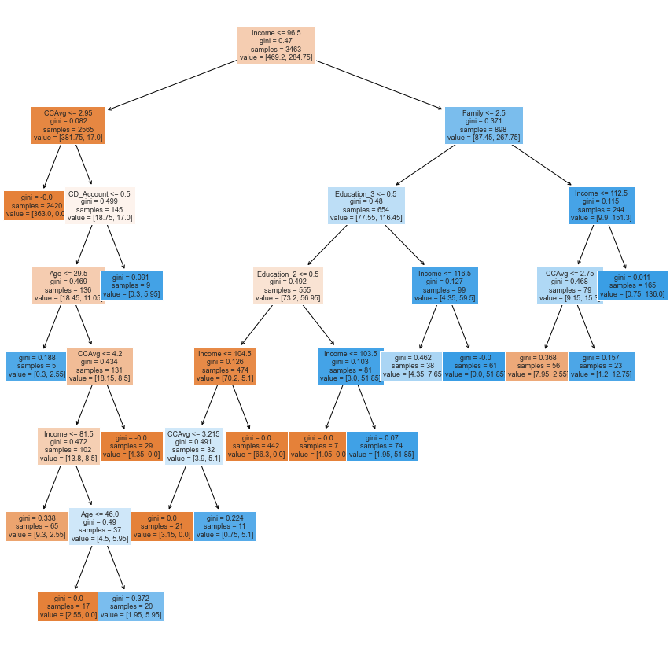

```python
plt.figure(figsize=(15,15))

out = tree.plot_tree(best_model,feature_names=feature_names,filled=True,fontsize=9,node_ids=False,class_names=None)
for o in out:
    arrow = o.arrow_patch
    if arrow is not None:
        arrow.set_edgecolor('black')
        arrow.set_linewidth(1)
plt.show()
```

```python
print(tree.export_text(best_model,feature_names=feature_names,show_weights=True))
```

```
|--- Income <= 96.50
|   |--- CCAvg <= 2.95
|   |   |--- weights: [363.00, 0.00] class: 0
|   |--- CCAvg >  2.95
|   |   |--- CD_Account <= 0.50
|   |   |   |--- Age <= 29.50
|   |   |   |   |--- weights: [0.30, 2.55] class: 1
|   |   |   |--- Age >  29.50
|   |   |   |   |--- CCAvg <= 4.20
|   |   |   |   |   |--- Income <= 81.50
|   |   |   |   |   |   |--- weights: [9.30, 2.55] class: 0
|   |   |   |   |   |--- Income >  81.50
|   |   |   |   |   |   |--- Age <= 46.00
|   |   |   |   |   |   |   |--- weights: [2.55, 0.00] class: 0
|   |   |   |   |   |   |--- Age >  46.00
|   |   |   |   |   |   |   |--- weights: [1.95, 5.95] class: 1
|   |   |   |   |--- CCAvg >  4.20
|   |   |   |   |   |--- weights: [4.35, 0.00] class: 0
|   |   |--- CD_Account >  0.50
|   |   |   |--- weights: [0.30, 5.95] class: 1
|--- Income >  96.50
|   |--- Family <= 2.50
|   |   |--- Education_3 <= 0.50
|   |   |   |--- Education_2 <= 0.50
|   |   |   |   |--- Income <= 104.50
|   |   |   |   |   |--- CCAvg <= 3.21
|   |   |   |   |   |   |--- weights: [3.15, 0.00] class: 0
|   |   |   |   |   |--- CCAvg >  3.21
|   |   |   |   |   |   |--- weights: [0.75, 5.10] class: 1
|   |   |   |   |--- Income >  104.50
|   |   |   |   |   |--- weights: [66.30, 0.00] class: 0
|   |   |   |--- Education_2 >  0.50
|   |   |   |   |--- Income <= 103.50
|   |   |   |   |   |--- weights: [1.05, 0.00] class: 0
|   |   |   |   |--- Income >  103.50
|   |   |   |   |   |--- weights: [1.95, 51.85] class: 1
|   |   |--- Education_3 >  0.50
|   |   |   |--- Income <= 116.50
|   |   |   |   |--- weights: [4.35, 7.65] class: 1
|   |   |   |--- Income >  116.50
|   |   |   |   |--- weights: [0.00, 51.85] class: 1
|   |--- Family >  2.50
|   |   |--- Income <= 112.50
|   |   |   |--- CCAvg <= 2.75
|   |   |   |   |--- weights: [7.95, 2.55] class: 0
|   |   |   |--- CCAvg >  2.75
|   |   |   |   |--- weights: [1.20, 12.75] class: 1
|   |   |--- Income >  112.50
|   |   |   |--- weights: [0.75, 136.00] class: 1
```

```python
print (pd.DataFrame(best_model.feature_importances_, columns = ["Imp"], index = X_train.columns).sort_values(by = 'Imp', ascending = False))
```

```
                         Imp
Income              0.629544
Education_2         0.148930
CCAvg               0.073993
Education_3         0.063778
Family              0.061412
Age                 0.011865
CD_Account          0.010479
Mortgage            0.000000
Securities_Account  0.000000
Online              0.000000
CreditCard          0.000000
ZIPSimple           0.000000
```

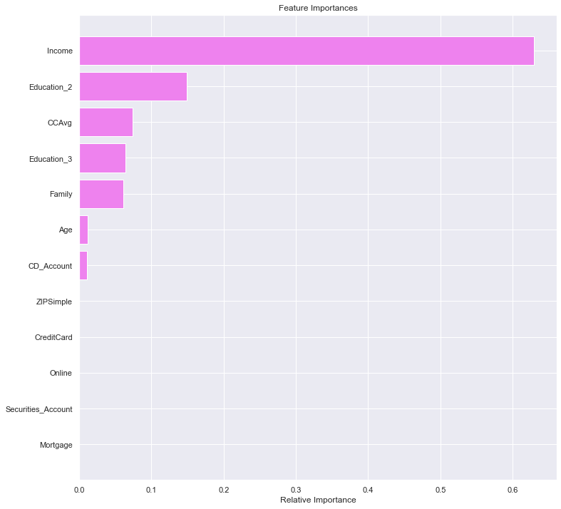

```python
importances = best_model.feature_importances_
indices = np.argsort(importances)

plt.figure(figsize=(12,12))
plt.title('Feature Importances')
plt.barh(range(len(indices)), importances[indices], color='violet', align='center')
plt.yticks(range(len(indices)), [feature_names[i] for i in indices])
plt.xlabel('Relative Importance')
plt.show()
```

#### Insights on tree after pruning using cost complexity analysis

1. The CCP alpha pruned tree has given us a tree with good results.
2. Here are the performances of the three trees we hav built.

##### Initial Tree:

Recall on training set : 1.0

Recall on test set : 0.8620689655172413

Precision on training set : 1.0

Precision on test set : 0.9259259259259259

F1 on training set : 1.0

F1 on test set : 0.8928571428571429

##### Tree from GridSearch algorithm

Recall on training set : 1.0

Recall on test set : 0.8620689655172413

Precision on training set : 1.0

Precision on test set : 0.9259259259259259

F1 on training set : 1.0

F1 on test set : 0.8928571428571429

##### Tree after Cost complexity analysis

Recall on training set : 0.982089552238806

Recall on test set : 0.9448275862068966

Precision on training set : 0.8103448275862069

Precision on test set : 0.8203592814371258

F1 on training set : 0.8879892037786775

F1 on test set : 0.8782051282051282

# 6. Analyze misclassified data

```python
evaluate1 = X_train.copy()
evaluate1['actual']=y_train
evaluate1['pred_train'] = best_model.predict(X_train)

# Collect indices of TP & TN rows
indexNames1 = evaluate1[ evaluate1['actual'] == evaluate1['pred_train'] ].index
# Collect indices of FN & FP rows
indexNames2 = evaluate1[ evaluate1['actual'] != evaluate1['pred_train'] ].index

evaluate2 = evaluate1.copy()

# Drop rows that constiture TP & TN - Evaluate1 is now the ste of rows that is misclassified
evaluate1.drop(indexNames1, inplace=True)

# Drop rows that constiture FN & FP - Evaluate2 is now the set of rows that is classified properly
evaluate2.drop(indexNames2, inplace=True)
```

```python
print("Describe Properly classified (TP + TN) data")
evaluate1.describe().T
```

[output not shown]

|  | count | mean | std | min | 25% | 50% | 75% | max |
| --- | --- | --- | --- | --- | --- | --- | --- | --- |
| Age | 83.0 | 46.361446 | 12.728476 | 25.0 | 34.0 | 46.0 | 59.0 | 66.0 |
| Income | 83.0 | 102.253012 | 11.521817 | 64.0 | 98.0 | 104.0 | 112.0 | 115.0 |
| Family | 83.0 | 1.963855 | 1.131002 | 1.0 | 1.0 | 2.0 | 2.5 | 4.0 |
| CCAvg | 83.0 | 2.640964 | 1.392930 | 0.1 | 1.5 | 2.9 | 3.8 | 5.2 |
| Mortgage | 83.0 | 70.108434 | 103.905857 | 0.0 | 0.0 | 0.0 | 182.5 | 252.5 |
| Securities_Account | 83.0 | 0.120482 | 0.327503 | 0.0 | 0.0 | 0.0 | 0.0 | 1.0 |
| CD_Account | 83.0 | 0.072289 | 0.260540 | 0.0 | 0.0 | 0.0 | 0.0 | 1.0 |
| Online | 83.0 | 0.638554 | 0.483340 | 0.0 | 0.0 | 1.0 | 1.0 | 1.0 |
| CreditCard | 83.0 | 0.301205 | 0.461570 | 0.0 | 0.0 | 0.0 | 1.0 | 1.0 |
| ZIPSimple | 83.0 | 931.168675 | 17.902731 | 900.0 | 920.0 | 934.0 | 946.0 | 959.0 |
| Education_2 | 83.0 | 0.265060 | 0.444048 | 0.0 | 0.0 | 0.0 | 1.0 | 1.0 |
| Education_3 | 83.0 | 0.469880 | 0.502126 | 0.0 | 0.0 | 0.0 | 1.0 | 1.0 |
| actual | 83.0 | 0.072289 | 0.260540 | 0.0 | 0.0 | 0.0 | 0.0 | 1.0 |
| pred_train | 83.0 | 0.927711 | 0.260540 | 0.0 | 1.0 | 1.0 | 1.0 | 1.0 |

```python
print("UG holders",(83-(evaluate1['Education_2'].sum())-(evaluate1['Education_3'].sum())) ,
      "Graduate holders", evaluate1['Education_2'].sum(),
      "Advanced degree holders", evaluate1['Education_3'].sum())
```

```
UG holders 22 Graduate holders 22 Advanced degree holders 39
```

```python
print("Describe Misclassified (FN + FP) data")
evaluate2.describe().T
```

[output not shown]

|  | count | mean | std | min | 25% | 50% | 75% | max |
| --- | --- | --- | --- | --- | --- | --- | --- | --- |
| Age | 3380.0 | 45.467456 | 11.240114 | 24.0 | 36.0 | 45.0 | 55.0 | 67.0 |
| Income | 3380.0 | 73.176183 | 46.118531 | 8.0 | 38.0 | 63.0 | 95.0 | 186.5 |
| Family | 3380.0 | 2.390237 | 1.142713 | 1.0 | 1.0 | 2.0 | 3.0 | 4.0 |
| CCAvg | 3380.0 | 1.842234 | 1.462431 | 0.0 | 0.7 | 1.5 | 2.6 | 5.2 |
| Mortgage | 3380.0 | 51.033728 | 83.174377 | 0.0 | 0.0 | 0.0 | 102.0 | 252.5 |
| Securities_Account | 3380.0 | 0.105325 | 0.307018 | 0.0 | 0.0 | 0.0 | 0.0 | 1.0 |
| CD_Account | 3380.0 | 0.055030 | 0.228072 | 0.0 | 0.0 | 0.0 | 0.0 | 1.0 |
| Online | 3380.0 | 0.592604 | 0.491422 | 0.0 | 0.0 | 1.0 | 1.0 | 1.0 |
| CreditCard | 3380.0 | 0.297337 | 0.457154 | 0.0 | 0.0 | 0.0 | 1.0 | 1.0 |
| ZIPSimple | 3380.0 | 931.159172 | 17.598346 | 900.0 | 919.0 | 934.0 | 946.0 | 966.0 |
| Education_2 | 3380.0 | 0.281953 | 0.450017 | 0.0 | 0.0 | 0.0 | 1.0 | 1.0 |
| Education_3 | 3380.0 | 0.292899 | 0.455160 | 0.0 | 0.0 | 0.0 | 1.0 | 1.0 |
| actual | 3380.0 | 0.097337 | 0.296460 | 0.0 | 0.0 | 0.0 | 0.0 | 1.0 |
| pred_train | 3380.0 | 0.097337 | 0.296460 | 0.0 | 0.0 | 0.0 | 0.0 | 1.0 |

```python
print("UG holders",(3380-(evaluate2['Education_2'].sum())-(evaluate2['Education_3'].sum())) ,
      "Graduate holders", evaluate2['Education_2'].sum(),
      "Advanced degree holders", evaluate1['Education_3'].sum())
```

```
UG holders 1437 Graduate holders 953 Advanced degree holders 39
```

## 6.1 Observations:

Insights:

1. A recommendation to the business would be to consider having separate buckets of customers - each with its own model. This way, each bucket can be fine tuned without imposing one solution on the entire data set

# 7. Conclusion & Recommendations

## 7.1 Conclusion

1. We analyzed the customer loan data using Logistic Regression and built a predictive model for the same
2. The model can be used to predict the likely hood of a customer signing up for a personal loan. We identified Education, CD Account, Family, Securities account as major factors that influence the likelihood of a customer signing up for a personal loan - in that order. In building the model, we identified an optimum value fo threshold for the dependent varible.
3. But business folks cant use a logistic regression to run targeted campaingns. They need a tool to segment the customers so that they reach their intended audience effectively. This is what a Decision Tree does for us.
4. We then built a decision tree which was overfitting in nature. We optimized the overfitting by performing a GridSearch algorithm. Unfortunately, the algorithmn did not yield an optimum tree. We subsequently did a cost complexity analysis using ccp_alpha values to arrive at an optimum tree. Income, Family, CCAvg and Education are important variables that influence the nature of this tree.

## 7.2 Recommendation

1. Marketing should segment customers along the following lines in that order - Income, CCAVg, Education, Family Size
2. Within the segmented subsections - Marketing should focus on targeting campaigns on customers with higher levels of eduation, followed by those that have ancilliary accounts like CD & Securities account.
3. Customers who have higher family sizes are also more likely to get personal loan.